# EMA Data Characteristics Report

Walter G. Dyer, wdyer@psu.edu, Penn State University

2026-03-26

```r
# Data management
library(dplyr)
library(tidyr)
library(here)
library(htmltools)

# EMA preprocessing tools
library(esmtools)

# Descriptive statistics
library(skimr)

# Multilevel modeling (for ICC estimation)
library(lme4)

# Missing values
library(naniar)
library(visdat)

# Plotting
library(ggplot2)

# Dates and times
library(lubridate)
library(hms)

# Tables
library(knitr)
library(kableExtra)
```

```r
# Section summary function
section_summary <- function(text) {
  htmltools::HTML(paste0(
    '<div class="section-summary">',
    '<span class="summary-label">Summary</span>',
    text,
    '</div>'
  ))
}

# Committee callout function
committee_note <- function(text) {
  htmltools::HTML(paste0(
    '<div class="committee-note">',
    '<span class="committee-label">Committee</span>',
    text,
    '</div>'
  ))
}

# Validity function (carried over from preprocessing report)
check_validity <- function(df) {
  mood_ok          <- !is.na(df$mood)
  before_survey_ok <- !is.na(df$before_survey)
  smoke_ok         <- !is.na(df$smoke)
  branch_ok        <- !is.na(df$pleasant) | !is.na(df$unpleasant)
  as.integer(mood_ok & before_survey_ok & smoke_ok & branch_ok)
}
```

```r
# Load preprocessed dataset from Report 1 output
study_sample <- readRDS(here("output", "cleaned_study_sample.RDS"))

# Part 6 completer IDs (any participant with Part 6 data)
part6_completers <- study_sample %>%
  filter(study_part == 6) %>%
  distinct(participant_id) %>%
  pull(participant_id)

# Valid Part 6 completer IDs (excludes participants with zero valid Part 6 obs,
# e.g., participant 223 who had missing branch variable data throughout Part 6)
valid_completers <- study_sample %>%
  mutate(valid = check_validity(.)) %>%
  filter(valid == 1, study_part == 6) %>%
  distinct(participant_id) %>%
  pull(participant_id)
```

# Overview

This report characterizes the preprocessed EMA dataset for Walter Dyer’s dissertation from the DVAL project parent study following Revol et al.’s (2024) data characteristics report guidelines. It describes the quality of the data collection, the properties of the key EMA variables, and selected preliminary analyses. Content flagged with a **Committee** label addresses questions raised during the proposal defense.

The preprocessed dataset was produced by the companion EMA Preprocessing Report and is loaded directly from that report’s output. All analyses here are conducted on the fully preprocessed dataset.

**Study summary:** Participants completed EMA surveys 6 times per day within predetermined 2-hour intervals. Part 2 (Days 1–3) was a baseline period during which participants were instructed to smoke at their normal rate. Part 6 (Days 4–10) was an incentivized abstinence period during which participants could earn daily cash bonuses for verified cigarette abstinence. EMA, baseline, and biochemical verification (CO) data are included in the preprocessed dataset.

# Variable Descriptions

# Sample Description

CommitteeThis section addresses committee questions about the demographic characteristics of the sample and the flow of participants through the study.

## Demographics

CommitteeThe committee requested a description of the demographic characteristics of the sample.

## CONSORT Diagram

CommitteeThe committee requested a CONSORT diagram to document participant flow through the study.

```r
library(DiagrammeR)

# Dynamically computed from study_sample
n_part2 <- study_sample %>%
  filter(study_part == 2) %>%
  distinct(participant_id) %>%
  nrow()

n_part6 <- study_sample %>%
  filter(study_part == 6) %>%
  distinct(participant_id) %>%
  nrow()

n_dropout <- n_part2 - n_part6

grViz(paste0('
digraph consort {

  graph [layout = dot, rankdir = TB, fontname = "Helvetica"]
  node  [shape = rectangle, fontname = "Helvetica", fontsize = 11,
         style = filled, fillcolor = white, margin = "0.2,0.1"]
  edge  [fontname = "Helvetica", fontsize = 10]

  # Main flow nodes
  screened   [label = "Screened via telephone\n(n = 1,187)"]
  consented  [label = "Consented\n(n = 139)"]
  baseline   [label = "Completed baseline laboratory visit\n(n = 118)"]
  part2      [label = "Completed 3-day baseline EMA and\nmet criteria for continuation\n(n = ', n_part2, ')"]
  mock       [label = "Completed mock scanner training visit\n(n = 82)"]
  randomized [label = "Randomized to scan order A (n = 41)\nor scan order B (n = 41)"]
  part6      [label = "Completed 7-day EMA period\nwith incentivized abstinence\n(n = ', n_part6, ')"]

  # Exclusion nodes
  excl1 [label = "Declined to participate (n = 189)\nNot eligible (n = 858)\nUnable to schedule: COVID-19 shutdown (n = 1)",
          shape = rectangle, fillcolor = "#f9f9f9"]
  excl2 [label = "Declined to continue (n = 2)\nScreened out: CPD below cutoff (n = 3)\nScreened out: baseline CO below cutoff (n = 5)\nScreened out: MRI-related exclusion (n = 6)\nScreened out: substance dependence on MINI (n = 5)",
          shape = rectangle, fillcolor = "#f9f9f9"]
  excl3 [label = "Declined to continue (n = 11)\nUnable to continue: COVID-19 shutdown (n = 3)\nWithdrawn: protocol compliance below threshold (n = 9)",
          shape = rectangle, fillcolor = "#f9f9f9"]
  excl4 [label = "Withdrawn: claustrophobia/discomfort (n = 6)\nWithdrawn: experimental CO above cutoff (n = 4)\nWithdrawn: MRI-related exclusion (n = 2)\nWithdrawn: repeated cancellations (n = 1)",
          shape = rectangle, fillcolor = "#f9f9f9"]
  excl5 [label = "Declined to continue (n = 10)\nDied (n = 1)",
          shape = rectangle, fillcolor = "#f9f9f9"]
  excl6 [label = "Dropout between Part 2 and Part 6\n(n = ', n_dropout, ')",
          shape = rectangle, fillcolor = "#f9f9f9"]

  # Main flow edges
  screened   -> consented
  consented  -> baseline
  baseline   -> part2
  part2      -> mock
  mock       -> randomized
  randomized -> part6

  # Exclusion edges
  screened   -> excl1   [arrowhead = none, style = dashed]
  consented  -> excl2   [arrowhead = none, style = dashed]
  baseline   -> excl3   [arrowhead = none, style = dashed]
  part2      -> excl4   [arrowhead = none, style = dashed]
  randomized -> excl5   [arrowhead = none, style = dashed]
  part6      -> excl6   [arrowhead = none, style = dashed]
}
'))
```

[interactive chart not shown]

# Response Behavior Quality

This section examines how well participants engaged with the EMA protocol.

## Compliance

```r
compliance_df <- study_sample %>%
  mutate(valid = check_validity(.)) %>%
  group_by(participant_id) %>%
  summarise(
    valid_beeps     = sum(valid, na.rm = TRUE),
    max_dayno       = max(dayno, na.rm = TRUE),
    total_possible  = if_else(max_dayno <= 3, 18L, 60L),
    completion_group = if_else(max_dayno <= 3,
                               "Part 2 Only (3 days)",
                               "Parts 2 + 6 (10 days)"),
    compliance      = valid_beeps / total_possible
  ) %>%
  ungroup()

# Summary by group
compliance_df %>%
  group_by(completion_group) %>%
  summarise(
    n                = n(),
    mean_valid_beeps = round(mean(valid_beeps), 1),
    mean_possible    = round(mean(total_possible), 1),
    mean_compliance  = round(mean(compliance), 3),
    min_compliance   = round(min(compliance), 3),
    max_compliance   = round(max(compliance), 3)
  ) %>%
  kable(caption = "Compliance summary by study completion group") %>%
  kable_styling(bootstrap_options = c("striped", "hover", "condensed"),
                full_width = FALSE)
```

Compliance summary by study completion group

| completion_group | n | mean_valid_beeps | mean_possible | mean_compliance | min_compliance | max_compliance |
| --- | --- | --- | --- | --- | --- | --- |
| Part 2 Only (3 days) | 36 | 10.4 | 18 | 0.580 | 0.167 | 1.000 |
| Parts 2 + 6 (10 days) | 59 | 34.9 | 60 | 0.582 | 0.033 | 0.983 |

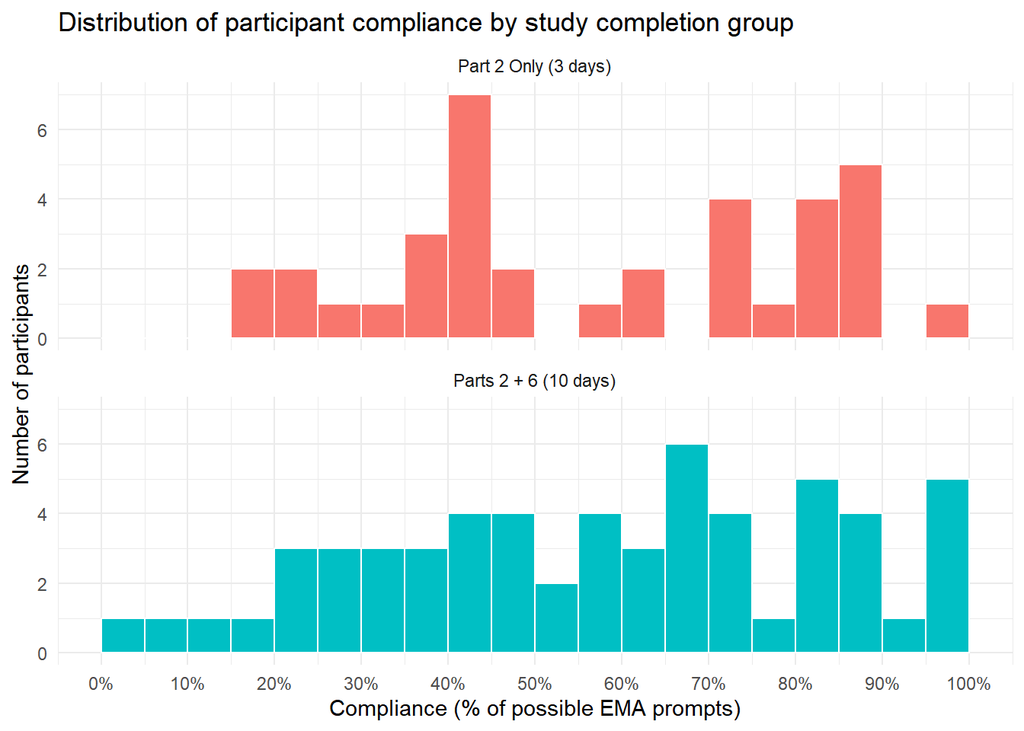

```r
ggplot(compliance_df, aes(x = compliance, fill = completion_group)) +
  geom_histogram(binwidth = 0.05, boundary = 0, color = "white") +
  scale_x_continuous(
    limits = c(0, 1),
    breaks = seq(0, 1, by = 0.1),
    labels = scales::percent_format(accuracy = 1)
  ) +
  facet_wrap(~ completion_group, ncol = 1) +
  labs(
    title = "Distribution of participant compliance by study completion group",
    x     = "Compliance (% of possible EMA prompts)",
    y     = "Number of participants"
  ) +
  theme_minimal() +
  theme(legend.position = "none")
```

## Compliance Trends and Participant Characteristics

CommitteeThe committee asked whether there are significant trends in non-compliance that should be accounted for (e.g., participant characteristics).

```r
# Merge compliance with baseline characteristics
compliance_chars <- compliance_df %>%
  left_join(
    study_sample %>%
      group_by(participant_id) %>%
      slice(1) %>%
      ungroup() %>%
      select(participant_id, age, gender, race,
             ftnd_sum, cigsperday, panas_pos, panas_neg),
    by = "participant_id"
  )

# Correlations between compliance and continuous baseline variables,
# with significance stars
cor_vars <- c("compliance", "age", "ftnd_sum", "cigsperday", "panas_pos", "panas_neg")

cor_data <- compliance_chars %>%
  select(all_of(cor_vars))

n_vars <- length(cor_vars)
r_mat  <- matrix(NA, n_vars, n_vars, dimnames = list(cor_vars, cor_vars))
p_mat  <- matrix(NA, n_vars, n_vars, dimnames = list(cor_vars, cor_vars))

for (i in seq_len(n_vars)) {
  for (j in seq_len(n_vars)) {
    if (i == j) {
      r_mat[i, j] <- 1
      p_mat[i, j] <- NA
    } else {
      test         <- cor.test(cor_data[[i]], cor_data[[j]],
                               use = "pairwise.complete.obs")
      r_mat[i, j] <- round(test$estimate, 3)
      p_mat[i, j] <- test$p.value
    }
  }
}

# Build display matrix with stars appended
sig_stars <- function(p) {
  if (is.na(p)) return("")
  if (p < .001) return("***")
  if (p < .01)  return("**")
  if (p < .05)  return("*")
  if (p < .10)  return(".")
  return("")
}

display_mat <- matrix("", n_vars, n_vars, dimnames = list(cor_vars, cor_vars))
for (i in seq_len(n_vars)) {
  for (j in seq_len(n_vars)) {
    if (i == j) {
      display_mat[i, j] <- "—"
    } else {
      display_mat[i, j] <- paste0(r_mat[i, j], sig_stars(p_mat[i, j]))
    }
  }
}

as.data.frame(display_mat) %>%
  kable(caption = "Correlations between compliance and baseline characteristics. * p < .05, ** p < .01, *** p < .001, . p < .10") %>%
  kable_styling(bootstrap_options = c("striped", "hover", "condensed"),
                full_width = FALSE)
```

Correlations between compliance and baseline characteristics. * p < .05, ** p < .01, *** p < .001, . p < .10

|  | compliance | age | ftnd_sum | cigsperday | panas_pos | panas_neg |
| --- | --- | --- | --- | --- | --- | --- |
| compliance | — | 0.016 | -0.017 | -0.059 | 0.22* | -0.177. |
| age | 0.016 | — | 0.273** | 0.364*** | 0.053 | -0.001 |
| ftnd_sum | -0.017 | 0.273** | — | 0.678*** | -0.078 | -0.024 |
| cigsperday | -0.059 | 0.364*** | 0.678*** | — | -0.062 | -0.062 |
| panas_pos | 0.22* | 0.053 | -0.078 | -0.062 | — | -0.343*** |
| panas_neg | -0.177. | -0.001 | -0.024 | -0.062 | -0.343*** | — |

## Validity Audit

CommitteeThe committee requested the number of available cases for each Aim.

```r
# Add valid column to full dataset first
study_sample_v <- study_sample %>%
  mutate(valid = check_validity(.))

# Now summarise per participant per part
validity_audit <- study_sample_v %>%
  group_by(participant_id, study_part) %>%
  summarise(
    n_total     = n(),
    n_mood_ok   = sum(!is.na(mood)),
    n_before_ok = sum(!is.na(before_survey)),
    n_smoke_ok  = sum(!is.na(smoke)),
    n_branch_ok = sum(!is.na(pleasant) | !is.na(unpleasant)),
    n_valid     = sum(valid),
    pct_valid   = round(sum(valid) / n() * 100, 1),
    .groups = "drop"
  ) %>%
  mutate(
    study_part = factor(study_part,
                        levels = c(2, 6),
                        labels = c("Part 2", "Part 6")),
    branch_limiting = n_mood_ok == n_smoke_ok &
                      n_smoke_ok == n_before_ok &
                      n_branch_ok < n_mood_ok
  )

# First table: participants where branch is limiting factor
validity_audit %>%
  filter(branch_limiting) %>%
  select(participant_id, study_part, n_total, n_mood_ok,
         n_branch_ok, n_valid, pct_valid) %>%
  arrange(participant_id, study_part) %>%
  kable(caption = "Participants where branch variable (pleasant/unpleasant) is the limiting validity factor") %>%
  kable_styling(bootstrap_options = c("striped", "hover", "condensed"),
                full_width = FALSE)
```

Participants where branch variable (pleasant/unpleasant) is the limiting validity factor

| participant_id | study_part | n_total | n_mood_ok | n_branch_ok | n_valid | pct_valid |
| --- | --- | --- | --- | --- | --- | --- |
| 102 | Part 2 | 18 | 17 | 12 | 12 | 66.7 |
| 102 | Part 6 | 42 | 39 | 28 | 28 | 66.7 |
| 104 | Part 2 | 18 | 17 | 12 | 12 | 66.7 |
| 104 | Part 6 | 41 | 37 | 15 | 15 | 36.6 |
| 112 | Part 2 | 18 | 18 | 8 | 8 | 44.4 |
| 112 | Part 6 | 42 | 41 | 17 | 17 | 40.5 |
| 113 | Part 2 | 18 | 17 | 13 | 13 | 72.2 |
| 115 | Part 2 | 18 | 16 | 9 | 9 | 50.0 |
| 116 | Part 2 | 18 | 17 | 11 | 11 | 61.1 |
| 116 | Part 6 | 42 | 32 | 2 | 2 | 4.8 |
| 124 | Part 2 | 18 | 17 | 6 | 6 | 33.3 |
| 124 | Part 6 | 41 | 40 | 21 | 21 | 51.2 |
| 125 | Part 2 | 18 | 17 | 16 | 16 | 88.9 |
| 125 | Part 6 | 42 | 40 | 35 | 35 | 83.3 |
| 126 | Part 2 | 18 | 18 | 11 | 11 | 61.1 |
| 126 | Part 6 | 42 | 40 | 17 | 17 | 40.5 |
| 127 | Part 2 | 17 | 14 | 13 | 13 | 76.5 |
| 128 | Part 2 | 18 | 18 | 1 | 1 | 5.6 |
| 128 | Part 6 | 42 | 39 | 5 | 5 | 11.9 |
| 141 | Part 2 | 17 | 15 | 12 | 12 | 70.6 |
| 141 | Part 6 | 42 | 41 | 24 | 24 | 57.1 |
| 150 | Part 2 | 18 | 14 | 7 | 7 | 38.9 |
| 151 | Part 2 | 18 | 17 | 9 | 9 | 50.0 |
| 151 | Part 6 | 41 | 33 | 23 | 23 | 56.1 |
| 154 | Part 2 | 18 | 18 | 7 | 7 | 38.9 |
| 154 | Part 6 | 42 | 39 | 21 | 21 | 50.0 |
| 159 | Part 2 | 18 | 17 | 12 | 12 | 66.7 |
| 159 | Part 6 | 41 | 40 | 39 | 39 | 95.1 |
| 163 | Part 2 | 18 | 18 | 12 | 12 | 66.7 |
| 163 | Part 6 | 42 | 31 | 19 | 19 | 45.2 |

[output cut: 105 more lines]

```r
# Wide format: drop branch_limiting before pivoting
validity_wide <- validity_audit %>%
  select(-branch_limiting) %>%
  pivot_wider(
    id_cols     = participant_id,
    names_from  = study_part,
    values_from = c(n_total, n_mood_ok, n_before_ok,
                    n_smoke_ok, n_branch_ok, n_valid, pct_valid),
    names_glue  = "{study_part}_{.value}"
  )

# Reattach branch_limiting flags per part after widening
branch_flags <- validity_audit %>%
  select(participant_id, study_part, branch_limiting) %>%
  pivot_wider(
    id_cols     = participant_id,
    names_from  = study_part,
    values_from = branch_limiting,
    names_glue  = "{study_part}_branch_limiting"
  )

validity_wide <- validity_wide %>%
  left_join(branch_flags, by = "participant_id")

# Full audit table
validity_wide %>%
  arrange(participant_id) %>%
  kable(caption = "Participant-level validity audit by study part. n_branch_ok = observations with at least one non-missing pleasant/unpleasant value.") %>%
  kable_styling(bootstrap_options = c("striped", "hover", "condensed"),
                full_width = FALSE) %>%
  scroll_box(height = "400px")
```

Participant-level validity audit by study part. n_branch_ok = observations with at least one non-missing pleasant/unpleasant value.

| participant_id | Part 2_n_total | Part 6_n_total | Part 2_n_mood_ok | Part 6_n_mood_ok | Part 2_n_before_ok | Part 6_n_before_ok | Part 2_n_smoke_ok | Part 6_n_smoke_ok | Part 2_n_branch_ok | Part 6_n_branch_ok | Part 2_n_valid | Part 6_n_valid | Part 2_pct_valid | Part 6_pct_valid | Part 2_branch_limiting | Part 6_branch_limiting |
| --- | --- | --- | --- | --- | --- | --- | --- | --- | --- | --- | --- | --- | --- | --- | --- | --- |
| 102 | 18 | 42 | 17 | 39 | 17 | 39 | 17 | 39 | 12 | 28 | 12 | 28 | 66.7 | 66.7 | TRUE | TRUE |
| 104 | 18 | 41 | 17 | 37 | 17 | 37 | 17 | 37 | 12 | 15 | 12 | 15 | 66.7 | 36.6 | TRUE | TRUE |
| 107 | 18 | 41 | 17 | 36 | 16 | 35 | 17 | 36 | 5 | 6 | 5 | 6 | 27.8 | 14.6 | FALSE | FALSE |
| 112 | 18 | 42 | 18 | 41 | 18 | 41 | 18 | 41 | 8 | 17 | 8 | 17 | 44.4 | 40.5 | TRUE | TRUE |
| 113 | 18 | NA | 17 | NA | 17 | NA | 17 | NA | 13 | NA | 13 | NA | 72.2 | NA | TRUE | NA |
| 115 | 18 | NA | 16 | NA | 16 | NA | 16 | NA | 9 | NA | 9 | NA | 50.0 | NA | TRUE | NA |
| 116 | 18 | 42 | 17 | 32 | 17 | 32 | 17 | 32 | 11 | 2 | 11 | 2 | 61.1 | 4.8 | TRUE | TRUE |
| 124 | 18 | 41 | 17 | 40 | 17 | 40 | 17 | 40 | 6 | 21 | 6 | 21 | 33.3 | 51.2 | TRUE | TRUE |
| 125 | 18 | 42 | 17 | 40 | 17 | 40 | 17 | 40 | 16 | 35 | 16 | 35 | 88.9 | 83.3 | TRUE | TRUE |
| 126 | 18 | 42 | 18 | 40 | 18 | 40 | 18 | 40 | 11 | 17 | 11 | 17 | 61.1 | 40.5 | TRUE | TRUE |
| 127 | 17 | NA | 14 | NA | 14 | NA | 14 | NA | 13 | NA | 13 | NA | 76.5 | NA | TRUE | NA |
| 128 | 18 | 42 | 18 | 39 | 18 | 39 | 18 | 39 | 1 | 5 | 1 | 5 | 5.6 | 11.9 | TRUE | TRUE |
| 133 | 18 | NA | 18 | NA | 18 | NA | 18 | NA | 18 | NA | 18 | NA | 100.0 | NA | FALSE | NA |
| 141 | 17 | 42 | 15 | 41 | 15 | 41 | 15 | 41 | 12 | 24 | 12 | 24 | 70.6 | 57.1 | TRUE | TRUE |
| 150 | 18 | NA | 14 | NA | 14 | NA | 14 | NA | 7 | NA | 7 | NA | 38.9 | NA | TRUE | NA |
| 151 | 18 | 41 | 17 | 33 | 17 | 33 | 17 | 33 | 9 | 23 | 9 | 23 | 50.0 | 56.1 | TRUE | TRUE |
| 154 | 18 | 42 | 18 | 39 | 18 | 39 | 18 | 39 | 7 | 21 | 7 | 21 | 38.9 | 50.0 | TRUE | TRUE |
| 159 | 18 | 41 | 17 | 40 | 17 | 40 | 17 | 40 | 12 | 39 | 12 | 39 | 66.7 | 95.1 | TRUE | TRUE |
| 163 | 18 | 42 | 18 | 31 | 18 | 31 | 18 | 31 | 12 | 19 | 12 | 19 | 66.7 | 45.2 | TRUE | TRUE |
| 164 | 18 | 40 | 15 | 37 | 15 | 37 | 15 | 37 | 14 | 5 | 14 | 5 | 77.8 | 12.5 | TRUE | TRUE |
| 166 | 18 | 41 | 18 | 35 | 18 | 35 | 18 | 35 | 17 | 32 | 17 | 32 | 94.4 | 78.0 | TRUE | TRUE |
| 169 | 18 | 42 | 18 | 41 | 18 | 41 | 18 | 41 | 15 | 22 | 15 | 22 | 83.3 | 52.4 | TRUE | TRUE |
| 175 | 18 | 42 | 18 | 42 | 18 | 42 | 18 | 42 | 9 | 33 | 9 | 33 | 50.0 | 78.6 | TRUE | TRUE |
| 177 | 18 | 41 | 18 | 41 | 18 | 40 | 18 | 41 | 18 | 40 | 18 | 40 | 100.0 | 97.6 | FALSE | FALSE |
| 180 | 18 | 42 | 17 | 42 | 17 | 42 | 17 | 42 | 6 | 10 | 6 | 10 | 33.3 | 23.8 | TRUE | TRUE |
| 186 | 18 | NA | 17 | NA | 17 | NA | 17 | NA | 4 | NA | 4 | NA | 22.2 | NA | TRUE | NA |
| 188 | 18 | NA | 17 | NA | 17 | NA | 17 | NA | 5 | NA | 5 | NA | 27.8 | NA | TRUE | NA |
| 192 | 18 | 42 | 16 | 42 | 16 | 42 | 16 | 42 | 4 | 13 | 4 | 13 | 22.2 | 31.0 | TRUE | TRUE |
| 195 | 18 | 42 | 16 | 39 | 16 | 39 | 16 | 39 | 16 | 38 | 16 | 38 | 88.9 | 90.5 | FALSE | TRUE |
| 196 | 18 | NA | 17 | NA | 17 | NA | 17 | NA | 15 | NA | 15 | NA | 83.3 | NA | TRUE | NA |

[output cut: 65 more lines]

SummaryAvailable cases for each Aim are determined by study part completion and observation-level validity criteria (see Validity Audit above for full details). Participant 223 is excluded from Part 6 analyses due to zero valid observations during that period. For Aims 1 and 2, which use Part 2 data, the full analytic sample is available. For Aim 3, which uses Part 6 data, the sample is limited to Part 6 completers with valid observations. Counts at varying validity thresholds are reported below. See Section 3 for the CONSORT diagram documenting participant flow through the study.

```r
# Available cases at different validity thresholds
bind_rows(lapply(c(40, 50, 60), function(cutoff) {
  validity_audit %>%
    group_by(study_part) %>%
    summarise(
      threshold = paste0(cutoff, "%"),
      n_retain  = sum(pct_valid >= cutoff, na.rm = TRUE),
      .groups = "drop"
    )
})) %>%
  pivot_wider(
    names_from  = study_part,
    values_from = n_retain,
    names_glue  = "{study_part}_n_retain"
  ) %>%
  arrange(threshold) %>%
  kable(caption = "Number of participants meeting validity thresholds by study part") %>%
  kable_styling(bootstrap_options = c("striped", "hover", "condensed"),
                full_width = FALSE)
```

Number of participants meeting validity thresholds by study part

| threshold | Part 2_n_retain | Part 6_n_retain |
| --- | --- | --- |
| 40% | 75 | 41 |
| 50% | 66 | 37 |
| 60% | 57 | 28 |

## Missingness

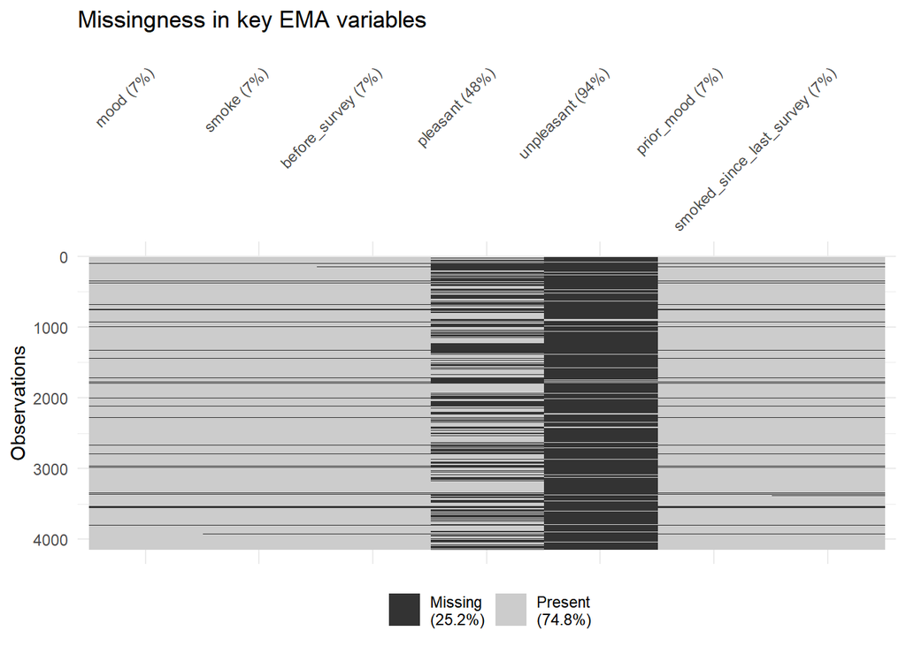

```r
vis_miss(study_sample %>% select(mood, smoke, before_survey,
                                  pleasant, unpleasant, prior_mood,
                                  smoked_since_last_survey)) +
  labs(title = "Missingness in key EMA variables") +
  theme(axis.text.x = element_text(angle = 45, hjust = 1))
```

## Beep Timing

# EMA Item Descriptives

This section describes the distributions, variance structure, and temporal patterns of the key EMA variables.

## Intraclass Correlations (ICCs)

CommitteeThe committee requested ICCs for key EMA variables to distinguish between- and within-person variance and justify modeling decisions.

```r
# Fit null models (random intercept only) and extract ICC
# ICC = between-person variance / (between-person variance + within-person variance)

compute_icc_lme4 <- function(df, var, id = "participant_id") {

  df_clean <- df %>%
    filter(!is.na(.data[[var]])) %>%
    rename(y = all_of(var), id_var = all_of(id))

  # Fit null model: outcome ~ 1 + (1 | participant)
  model <- lmer(y ~ 1 + (1 | id_var), data = df_clean, REML = TRUE)

  vc <- as.data.frame(VarCorr(model))

  between_var <- vc$vcov[vc$grp == "id_var"]
  within_var  <- vc$vcov[vc$grp == "Residual"]
  total_var   <- between_var + within_var
  icc         <- between_var / total_var

  tibble(
    variable    = var,
    icc         = round(icc, 3),
    between_var = round(between_var, 3),
    within_var  = round(within_var, 3),
    total_var   = round(total_var, 3),
    pct_between = round(icc * 100, 1),
    pct_within  = round((1 - icc) * 100, 1)
  )
}

ema_valid <- study_sample %>%
  mutate(valid = check_validity(.)) %>%
  filter(valid == 1)

icc_results <- bind_rows(
  lapply(c("mood", "smoke", "pleasant", "unpleasant", "prior_mood"),
         compute_icc_lme4, df = ema_valid)
)

icc_results %>%
  kable(caption = "Intraclass correlations (ICCs) for key EMA variables. ICCs were estimated using null models (random intercept only) fit with REML via lme4. Between-person variance reflects stable individual differences; within-person variance reflects moment-to-moment fluctuation.") %>%
  kable_styling(bootstrap_options = c("striped", "hover", "condensed"),
                full_width = FALSE)
```

Intraclass correlations (ICCs) for key EMA variables. ICCs were estimated using null models (random intercept only) fit with REML via lme4. Between-person variance reflects stable individual differences; within-person variance reflects moment-to-moment fluctuation.

| variable | icc | between_var | within_var | total_var | pct_between | pct_within |
| --- | --- | --- | --- | --- | --- | --- |
| mood | 0.320 | 150.467 | 319.977 | 470.444 | 32.0 | 68.0 |
| smoke | 0.321 | 274.991 | 580.881 | 855.871 | 32.1 | 67.9 |
| pleasant | 0.450 | 179.375 | 218.872 | 398.247 | 45.0 | 55.0 |
| unpleasant | 0.331 | 233.533 | 471.288 | 704.821 | 33.1 | 66.9 |
| prior_mood | 0.359 | 137.726 | 245.867 | 383.592 | 35.9 | 64.1 |

## Condition-Level Means

CommitteeThe committee requested means for mood and craving across unpleasant, pleasant, and neutral event appraisal conditions.

```r
study_sample %>%
  mutate(valid = check_validity(.)) %>%
  filter(valid == 1, !is.na(before_survey)) %>%
  group_by(before_survey) %>%
  summarise(
    n          = n(),
    mean_mood  = round(mean(mood, na.rm = TRUE), 2),
    sd_mood    = round(sd(mood, na.rm = TRUE), 2),
    mean_smoke = round(mean(smoke, na.rm = TRUE), 2),
    sd_smoke   = round(sd(smoke, na.rm = TRUE), 2)
  ) %>%
  kable(caption = "Means and SDs for mood and craving by event appraisal condition") %>%
  kable_styling(bootstrap_options = c("striped", "hover", "condensed"),
                full_width = FALSE)
```

Means and SDs for mood and craving by event appraisal condition

| before_survey | n | mean_mood | sd_mood | mean_smoke | sd_smoke |
| --- | --- | --- | --- | --- | --- |
| It was generally pleasant | 2168 | 68.60 | 17.94 | 44.68 | 28.99 |
| It was generally unpleasant | 269 | 31.88 | 20.48 | 62.59 | 28.52 |

# Smoking Behavior

CommitteeThis section addresses several committee questions about cigarette use behavior over the course of the study.

## Person-Level Cigarette Use

CommitteeThe committee requested a description of person-level cigarette use behavior over the course of the study.

## 3-Day Baseline Smoking

CommitteeThe committee requested that 3-day EMA cigarette smoking data be used to calculate each participant's typical smoking behavior as a baseline metric for assessing relative deviations during Part 6.

```r
# --- Table 1: Part 2 vs Part 6 smoking summary for completers ---

# Part 2 summary — all participants
part2_all <- study_sample %>%
  mutate(valid = check_validity(.)) %>%
  filter(valid == 1, study_part == 2, !is.na(smoked_since_last_survey)) %>%
  group_by(participant_id) %>%
  summarise(
    baseline_total = sum(smoked_since_last_survey, na.rm = TRUE),
    baseline_days  = n_distinct(dayno),
    baseline_daily = round(baseline_total / baseline_days, 2),
    .groups = "drop"
  )

# Part 2 summary — completers only
part2_completers <- part2_all %>%
  filter(participant_id %in% part6_completers)

# Part 6 summary — completers only
part6_summary <- study_sample %>%
  mutate(valid = check_validity(.)) %>%
  filter(valid == 1, study_part == 6, !is.na(smoked_since_last_survey)) %>%
  group_by(participant_id) %>%
  summarise(
    part6_total = sum(smoked_since_last_survey, na.rm = TRUE),
    part6_days  = n_distinct(dayno),
    part6_daily = round(part6_total / part6_days, 2),
    .groups = "drop"
  )

# Build comparison table
tibble(
  Sample = c("Part 2 completers",
           "Part 6 completers — Part 2 (baseline)",
           "Part 6 completers — Part 6 (incentive)"),
N = c(
  nrow(part2_completers),
  nrow(part2_completers),
  nrow(part6_summary)
),
Mean_daily = c(
  round(mean(part2_completers$baseline_daily, na.rm = TRUE), 2),
  round(mean(part2_completers$baseline_daily, na.rm = TRUE), 2),
  round(mean(part6_summary$part6_daily, na.rm = TRUE), 2)
),
  SD_daily = c(
    round(sd(part2_completers$baseline_daily, na.rm = TRUE), 2),
    round(sd(part2_completers$baseline_daily, na.rm = TRUE), 2),
    round(sd(part6_summary$part6_daily, na.rm = TRUE), 2)
  ),
  Min_daily = c(
    min(part2_completers$baseline_daily, na.rm = TRUE),
    min(part2_completers$baseline_daily, na.rm = TRUE),
    min(part6_summary$part6_daily, na.rm = TRUE)
  ),
  Max_daily = c(
    max(part2_completers$baseline_daily, na.rm = TRUE),
    max(part2_completers$baseline_daily, na.rm = TRUE),
    max(part6_summary$part6_daily, na.rm = TRUE)
  )
) %>%
  kable(caption = "Daily cigarette use summary by sample and study part") %>%
  kable_styling(bootstrap_options = c("striped", "hover", "condensed"),
                full_width = FALSE)
```

Daily cigarette use summary by sample and study part

[output not shown]

```r
# --- Table 2: Change category summary ---
# Recompute person_class here in case chunk is run independently
person_class_summary <- part2_completers %>%
  left_join(part6_summary, by = "participant_id") %>%
  mutate(
    change_cat = case_when(
      part6_daily <= 0.1                          ~ "Quitter",
      part6_daily < baseline_daily * 0.80         ~ "Reducer",
      part6_daily > baseline_daily * 1.20         ~ "Increaser",
      TRUE                                         ~ "Stable"
    )
  )

person_class_summary %>%
  group_by(change_cat) %>%
  summarise(
    n                    = n(),
    pct                  = round(n() / nrow(person_class_summary) * 100, 1),
    mean_baseline_daily  = round(mean(baseline_daily, na.rm = TRUE), 2),
    sd_baseline_daily    = round(sd(baseline_daily, na.rm = TRUE), 2),
    mean_part6_daily     = round(mean(part6_daily, na.rm = TRUE), 2),
    sd_part6_daily       = round(sd(part6_daily, na.rm = TRUE), 2),
    .groups = "drop"
  ) %>%
  arrange(desc(n)) %>%
  kable(caption = "Part 6 smoking change categories relative to Part 2 baseline. Quitter = mean Part 6 daily smoking <= 0.1; Reducer = >20% below baseline; Increaser = >20% above baseline; Stable = within 20% of baseline.") %>%
  kable_styling(bootstrap_options = c("striped", "hover", "condensed"),
                full_width = FALSE)
```

Part 6 smoking change categories relative to Part 2 baseline. Quitter = mean Part 6 daily smoking <= 0.1; Reducer = >20% below baseline; Increaser = >20% above baseline; Stable = within 20% of baseline.

| change_cat | n | pct | mean_baseline_daily | sd_baseline_daily | mean_part6_daily | sd_part6_daily |
| --- | --- | --- | --- | --- | --- | --- |
| Reducer | 25 | 42.4 | 10.06 | 5.40 | 3.36 | 2.68 |
| Quitter | 19 | 32.2 | 8.45 | 4.67 | 0.00 | 0.00 |
| Stable | 10 | 16.9 | 6.90 | 4.40 | 7.49 | 4.69 |
| Increaser | 5 | 8.5 | 5.83 | 3.10 | 8.61 | 4.18 |

## CO and EMA Alignment

CommitteeThe committee asked whether the CO data align with the EMA data on cigarette smoking for each participant.

# Abstinence Incentive

CommitteeThis section addresses the committee's question about the effect of the abstinence incentive. Analyses are framed descriptively to inform future modeling decisions.

```r
# Compare smoking behavior between Part 2 and Part 6
incentive_compare <- study_sample %>%
  mutate(valid = check_validity(.)) %>%
  filter(valid == 1, !is.na(smoked_since_last_survey)) %>%
  group_by(participant_id, study_part) %>%
  summarise(
    mean_smoked = mean(smoked_since_last_survey, na.rm = TRUE),
    .groups = "drop"
  ) %>%
  mutate(study_part = factor(study_part,
                              levels = c(2, 6),
                              labels = c("Part 2 (Baseline)", "Part 6 (Incentive)")))

# Summary
incentive_compare %>%
  group_by(study_part) %>%
  summarise(
    n           = n(),
    mean_smoked = round(mean(mean_smoked, na.rm = TRUE), 2),
    sd_smoked   = round(sd(mean_smoked, na.rm = TRUE), 2)
  ) %>%
  kable(caption = "Mean cigarettes reported per beep by study part") %>%
  kable_styling(bootstrap_options = c("striped", "hover", "condensed"),
                full_width = FALSE)
```

Mean cigarettes reported per beep by study part

| study_part | n | mean_smoked | sd_smoked |
| --- | --- | --- | --- |
| Part 2 (Baseline) | 95 | 2.26 | NA |
| Part 6 (Incentive) | 58 | 0.95 | NA |

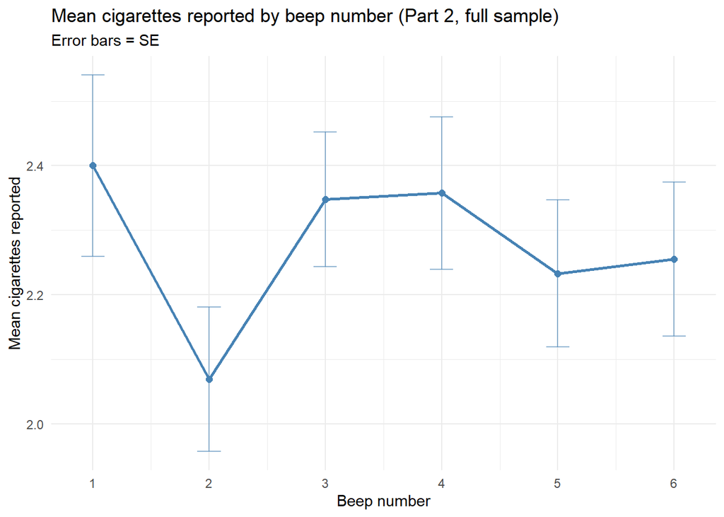

```r
# --- Plot 1: Mean cigarettes by beep number, Part 2 only, full sample ---
plot1_data <- study_sample %>%
  mutate(valid = check_validity(.)) %>%
  filter(valid == 1, study_part == 2, !is.na(smoked_since_last_survey),
         !is.na(beepno)) %>%
  group_by(beepno) %>%
  summarise(
    mean_smoked = mean(smoked_since_last_survey, na.rm = TRUE),
    sd_smoked   = sd(smoked_since_last_survey, na.rm = TRUE),
    n           = n(),
    se_smoked   = sd_smoked / sqrt(n),
    .groups = "drop"
  )

ggplot(plot1_data, aes(x = beepno, y = mean_smoked)) +
  geom_line(color = "steelblue", linewidth = 1) +
  geom_point(color = "steelblue", size = 2) +
  geom_errorbar(aes(ymin = mean_smoked - se_smoked,
                    ymax = mean_smoked + se_smoked),
                width = 0.2, color = "steelblue", alpha = 0.6) +
  scale_x_continuous(breaks = 1:6) +
  labs(
    title    = "Mean cigarettes reported by beep number (Part 2, full sample)",
    subtitle = "Error bars = SE",
    x        = "Beep number",
    y        = "Mean cigarettes reported"
  ) +
  theme_minimal()
```

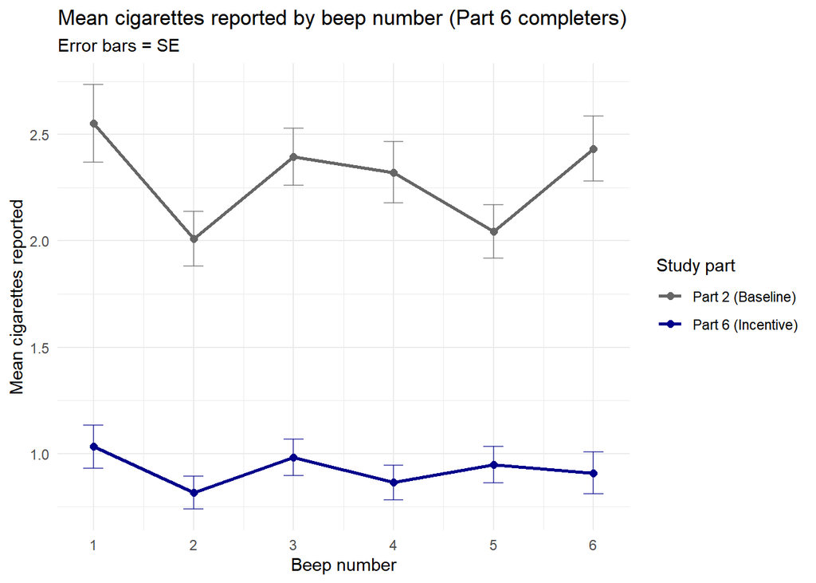

```r
# --- Plot 2: Mean cigarettes by beep number, Part 6 completers,
#             Part 2 vs Part 6 ---
plot2_data <- study_sample %>%
  mutate(valid = check_validity(.)) %>%
  filter(valid == 1,
         participant_id %in% valid_completers,
         !is.na(smoked_since_last_survey),
         !is.na(beepno)) %>%
  mutate(study_part = factor(study_part,
                              levels = c(2, 6),
                              labels = c("Part 2 (Baseline)",
                                         "Part 6 (Incentive)"))) %>%
  group_by(beepno, study_part) %>%
  summarise(
    mean_smoked = mean(smoked_since_last_survey, na.rm = TRUE),
    sd_smoked   = sd(smoked_since_last_survey, na.rm = TRUE),
    n           = n(),
    se_smoked   = sd_smoked / sqrt(n),
    .groups = "drop"
  )

ggplot(plot2_data, aes(x = beepno, y = mean_smoked,
                        color = study_part, group = study_part)) +
  geom_line(linewidth = 1) +
  geom_point(size = 2) +
  geom_errorbar(aes(ymin = mean_smoked - se_smoked,
                    ymax = mean_smoked + se_smoked),
                width = 0.2, alpha = 0.6) +
  scale_color_manual(values = c("Part 2 (Baseline)"  = "gray40",
                                 "Part 6 (Incentive)" = "darkblue")) +
  scale_x_continuous(breaks = 1:6) +
  labs(
    title    = "Mean cigarettes reported by beep number (Part 6 completers)",
    subtitle = "Error bars = SE",
    x        = "Beep number",
    y        = "Mean cigarettes reported",
    color    = "Study part"
  ) +
  theme_minimal()
```

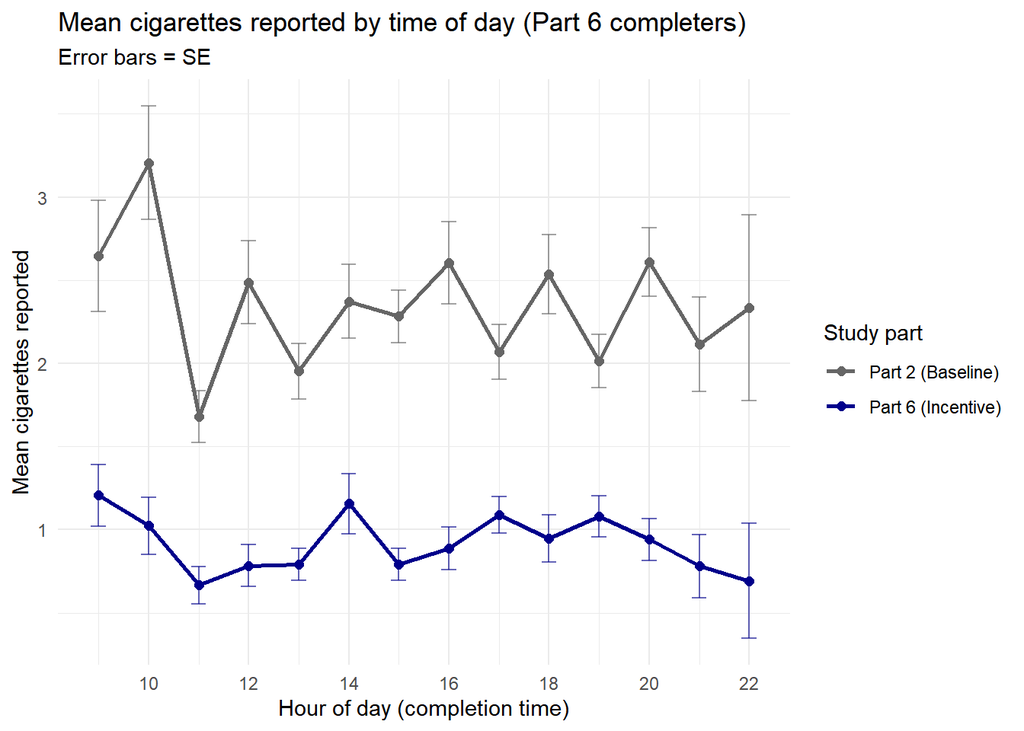

```r
# --- Plot 3: Time of day effects by study part, Part 6 completers ---
plot3_data <- study_sample %>%
  mutate(valid = check_validity(.)) %>%
  filter(valid == 1,
         participant_id %in% valid_completers,
         !is.na(smoked_since_last_survey),
         !is.na(completion_time)) %>%
  mutate(
    hour       = hour(completion_time),
    study_part = factor(study_part,
                         levels = c(2, 6),
                         labels = c("Part 2 (Baseline)",
                                    "Part 6 (Incentive)"))
  ) %>%
  group_by(hour, study_part) %>%
  summarise(
    mean_smoked = mean(smoked_since_last_survey, na.rm = TRUE),
    sd_smoked   = sd(smoked_since_last_survey, na.rm = TRUE),
    n           = n(),
    se_smoked   = sd_smoked / sqrt(n),
    .groups = "drop"
  )

ggplot(plot3_data, aes(x = hour, y = mean_smoked,
                        color = study_part, group = study_part)) +
  geom_line(linewidth = 1) +
  geom_point(size = 2) +
  geom_errorbar(aes(ymin = mean_smoked - se_smoked,
                    ymax = mean_smoked + se_smoked),
                width = 0.3, alpha = 0.6) +
  scale_color_manual(values = c("Part 2 (Baseline)"  = "gray40",
                                 "Part 6 (Incentive)" = "darkblue")) +
  scale_x_continuous(breaks = seq(6, 22, by = 2)) +
  labs(
    title    = "Mean cigarettes reported by time of day (Part 6 completers)",
    subtitle = "Error bars = SE",
    x        = "Hour of day (completion time)",
    y        = "Mean cigarettes reported",
    color    = "Study part"
  ) +
  theme_minimal()
```

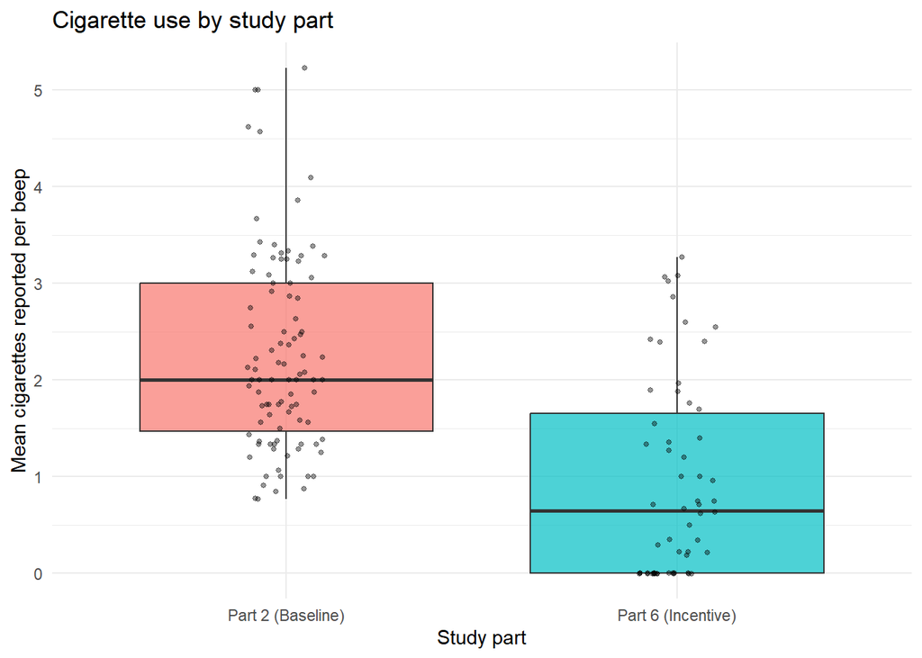

```r
ggplot(incentive_compare, aes(x = study_part, y = mean_smoked,
                               fill = study_part)) +
  geom_boxplot(alpha = 0.7) +
  geom_jitter(width = 0.1, alpha = 0.4, size = 1) +
  labs(
    title = "Cigarette use by study part",
    x     = "Study part",
    y     = "Mean cigarettes reported per beep"
  ) +
  theme_minimal() +
  theme(legend.position = "none")
```

*Note: Formal tests of the incentive effect are reserved for the main analyses. The above is intended to inform whether smoking behavior changed between parts and whether this should be considered in future modeling.*

SummaryDescriptive comparisons of smoking behavior between Part 2 and Part 6 suggest a meaningful reduction in cigarettes reported per beep during the incentivized abstinence period. Individual variability in response to the incentive is substantial, as reflected in the wide distributions. These results are framed descriptively and will inform whether study part or incentive-related variables need to be accounted for in the main analyses.

# Available Cases

CommitteeThe committee requested the number of available cases for each Aim, including a CONSORT diagram.

Available cases by Aim are summarized in the Validity Audit section above. See Section 3 for the CONSORT diagram.

# References

Revol, J., Carlier, C., Lafit, G., Verhees, M., Sels, L., & Ceulemans, E. (2024). Preprocessing ESM data: A step-by-step framework, tutorial website, R package, and reporting templates. *Advances in Methods and Practices in Psychological Science, 7*(4), 1–18. https://doi.org/10.1177/25152459241256609

Siepe, B. S., Rieble, C., Tutunji, R., Rimpler, A., März, J., Proppert, R. K. K., & Fried, E. I. (2024). Understanding EMA data: A tutorial on exploring item performance in ecological momentary assessment data. *PsyArXiv*. https://doi.org/10.31234/osf.io/dvj8g